# Childes-q

Kyle MacDonald

2/20/2017

## Set up

```r
rm(list=ls())
library(magrittr)
library(stringr)
library(tidyverse)
library(RMySQL)
library(directlabels)
theme_set(ggthemes::theme_few())
```

## Connect to the CHILDES db

Code adapted from the `dplyr` databases [vignette](https://cran.r-project.org/web/packages/dplyr/vignettes/databases.html)

Note that prior to running this code, you need to make sure that the mysql server is running. In the terminal, run: `mysql.server start`

```r
db <- src_mysql(host = "localhost", user='root', password='mbrllngs12', dbname='childes')
```

Get the relevant tables from the database

```r
corpora_meta_data <- tbl(db, "corpora")
kid_meta_data <- tbl(db, "children")
words <- tbl(db, "words")
```

## Extract all utterances with question words

```r
# start the clock
ptm <- proc.time()

all_qs <- words %>%
  filter(gloss %in% c("why", "what", "where", "when", "which", "how", "who", "whose", "whom" )) %>%
  collect(n = Inf)

# Stop the clock
proc.time() - ptm
```

```
##    user  system elapsed
##   2.019   0.179  18.995
```

Clean up the data

```r
days_in_month <- 30.436875

all_questions <- all_qs %>%
  select(gloss,speaker, mor, participants, gender, age, child, corpus,
         sentgloss, utt_number) %>%
  filter(speaker %in% c("MOT", "CHI", "DAD", "FAT")) %>%
  mutate(age_months = round(age / days_in_month, 0),
         child_clean = ifelse(child == "--", corpus, child),
         speaker_clean = ifelse(speaker == "CHI", "child", "parent"),
         parent_type = ifelse(speaker == "MOT", "mother", "father"))
```

```r
all_questions %<>%
  mutate(gloss_clean = ifelse(str_detect(gloss, "why"), "why",
                              ifelse(str_detect(gloss, "what"), "what",
                                     ifelse(str_detect(gloss, "where"), "where",
                                            ifelse(str_detect(gloss, "who"), "who",
                                                   ifelse(str_detect(gloss, "how"), "how",
                                                          ifelse(str_detect(gloss, "when"), "when",
                                                                 ifelse(str_detect(gloss, "which"), "which",
                                                                        ifelse(str_detect(gloss, "whose"), "whose",
                                                                               ifelse(str_detect(gloss, "whom"), "whom",
                                                                               "other"))))))))),
         utt_number = as.numeric(utt_number))
```

Get max utterance number for each recording, so we can normalize.

```r
tmp <- all_questions %>%
  group_by(child_clean, age_months) %>%
  mutate(utt_number = as.numeric(utt_number)) %>%
  summarise(length_transcript = max(utt_number))

all_questions %<>% left_join(., tmp, by = c("child_clean", "age_months"))
```

## Descriptives

```r
all_questions %>% distinct(corpus)
```

```
## # A tibble: 8 × 1
##       corpus
##        <chr>
## 1      Bloom
## 2     Suppes
## 3 Providence
## 4      Brown
## 5     Kuczaj
## 6      Sachs
## 7 Manchester
## 8     Thomas
```

```r
all_questions %>%
  distinct(child) %>%
  nrow() %>%
  paste("n children =", .)
```

```
## [1] "n children = 28"
```

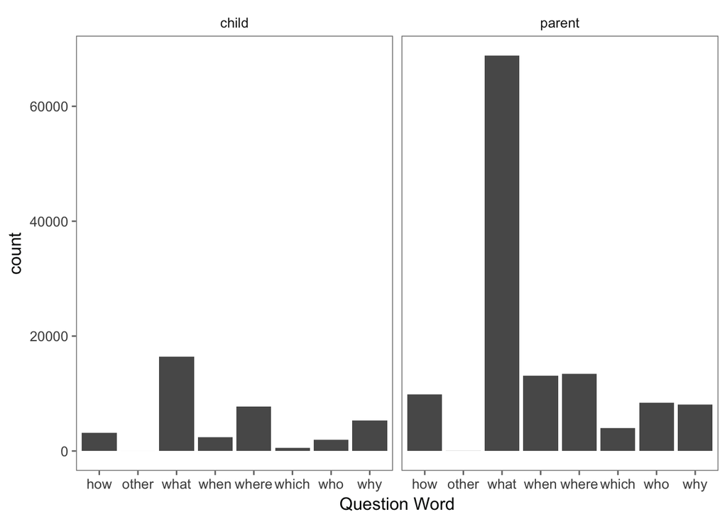

```r
all_questions %>%
  ungroup() %>%
  group_by(speaker_clean, gloss_clean, length_transcript) %>%
  summarise(count = n()) %>%
  ggplot(., aes(x = gloss_clean, y = count)) +
  geom_bar(stat = "identity") +
  labs(x = "Question Word") +
  facet_wrap(~speaker_clean)
```

```r
all_questions %>%
  group_by(speaker_clean, parent_type) %>%
  summarise(count = n())
```

```
## Source: local data frame [3 x 3]
## Groups: speaker_clean [?]
##
##   speaker_clean parent_type  count
##           <chr>       <chr>  <int>
## 1         child      father  37427
## 2        parent      father   6622
## 3        parent      mother 118914
```

```r
summary(all_questions$age_months)
```

```
##    Min. 1st Qu.  Median    Mean 3rd Qu.    Max.    NA's
##   11.00   27.00   32.00   33.06   37.00   62.00     117
```

```r
all_questions %>%
  filter(speaker_clean == "child") %>%
  select(gloss_clean, sentgloss, age_months) %>%
  group_by(gloss_clean) %>%
  sample_n(., size = 2) %>%
  knitr::kable()
```

| gloss_clean | sentgloss | age_months |
| --- | --- | --- |
| how | how dare you | 58 |
| how | &uh this how you make a l | 53 |
| other | no I don’t know how to say a toothpick Why that’s a toothpick | 34 |
| other | What are you going to do today | 40 |
| what | what you call this | 44 |
| what | now I know what to make | 59 |
| when | it’s just like when I cry | 33 |
| when | when is you gonna go tonight | 50 |
| where | where is it | 62 |
| where | where 0has Mummy gone | 34 |
| which | which way it were | 40 |
| which | which one | 33 |
| who | who is that | 28 |
| who | who that | 30 |
| why | why excuse me | 27 |
| why | and Dad’s gonna have yogurt dressing Mom why do you want spaghetti | 58 |

## Exploratory analyses

Count different kinds of questions for each kid and plot as a function of age.

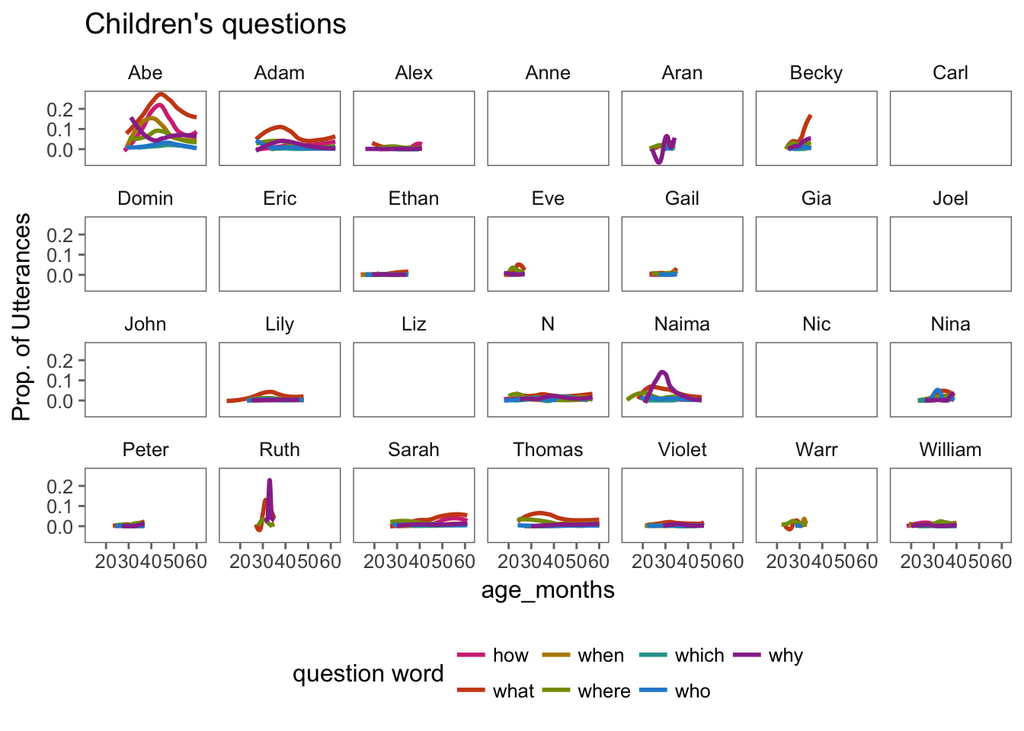

```r
all_questions %>%
  filter(speaker == "CHI") %>%
  group_by(child_clean, age_months, gloss_clean, length_transcript) %>%
  summarise(freq = n()) %>%
  filter(freq > 0) %>%
  mutate(prop = freq / length_transcript) %>%
  ggplot(., aes(x = age_months, y = prop, color = gloss_clean)) +
  geom_smooth(method = "loess", se = F) +
  labs(color = "question word", y = "Prop. of Utterances") +
  langcog::scale_color_solarized() +
  facet_wrap(~child_clean, ncol = 7) +
  theme(legend.position = "bottom") +
  ggtitle("Children's questions")
```

Count different kinds of questions for each parent and summarise over development

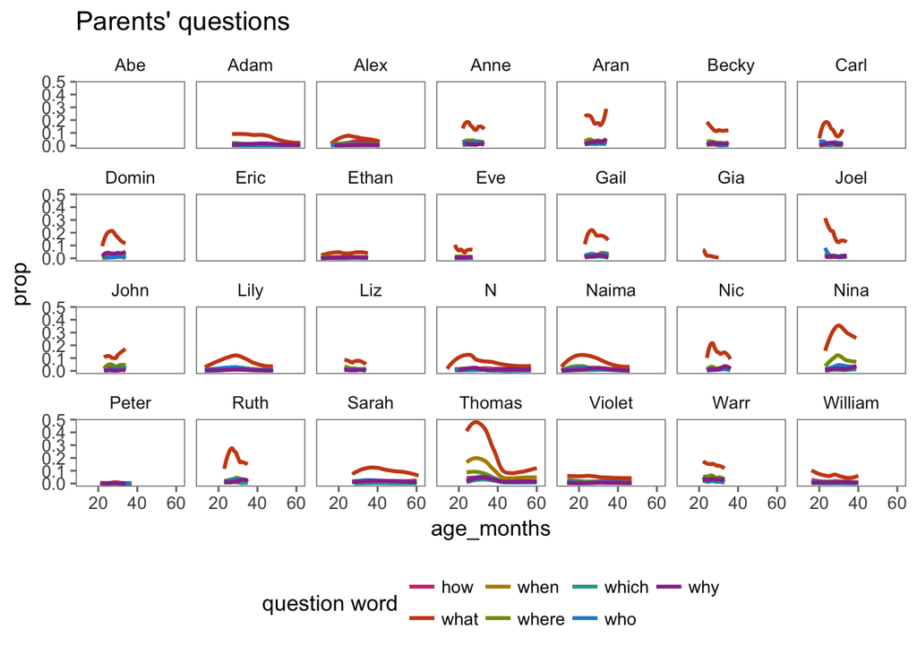

```r
all_questions %>%
  filter(speaker_clean == "parent") %>%
  group_by(child_clean, age_months, gloss_clean, length_transcript) %>%
  summarise(freq = n()) %>%
  filter(freq > 0) %>%
  mutate(prop = freq / length_transcript) %>%
  ggplot(., aes(x = age_months, y = prop, color = gloss_clean)) +
  geom_smooth(method = "loess", se = F) +
  labs(color = "question word") +
  langcog::scale_color_solarized() +
  facet_wrap(~child_clean, ncol = 7) +
  theme(legend.position = "bottom") +
  ggtitle("Parents' questions")
```

Now get the average frequency for each question type at each month of development.

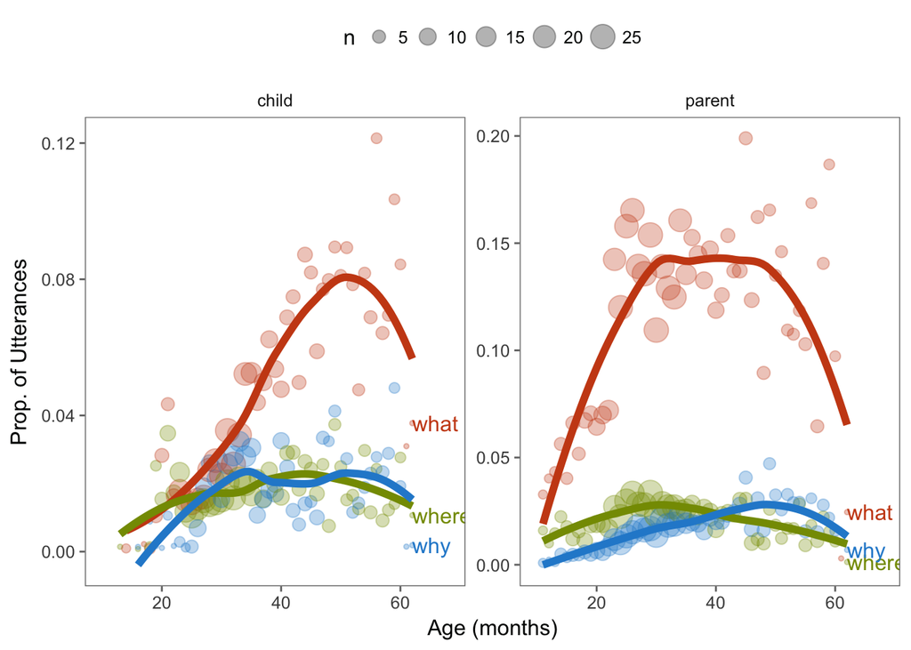

```r
all_questions %>%
  filter(gloss_clean %in% c('what', 'where', 'why')) %>%
  group_by(child_clean, age_months, gloss_clean, speaker_clean, length_transcript) %>%
  summarise(freq = n()) %>%
  filter(freq > 0) %>%
  mutate(prop = freq / length_transcript) %>%
  group_by(age_months, gloss_clean, speaker_clean) %>%
  summarise(m = mean(prop, na.rm = T),
            n = n()) %>%
  ggplot(., aes(x = age_months, y = m, color = gloss_clean)) +
  geom_point(aes(size = n), alpha = 0.3) +
  geom_smooth(se=F, method = "loess", size = 2) +
  xlim(10, 68) +
  labs(y = "Prop. of Utterances", x= "Age (months)") +
  guides(color = F) +
  langcog::scale_color_solarized() +
  geom_dl(aes(label = gloss_clean), method=list("last.points")) +
  facet_wrap(~speaker_clean, scales = "free") +
  theme(legend.position = "top")
```

### Gender analysis

```r
gender_ms <- all_questions %>%
  group_by(child_clean, gloss_clean, speaker, gender) %>%
  summarise(freq = n()) %>%
  filter(freq > 0, gender %in% c("male", "female")) %>%
  group_by(gloss_clean, speaker, gender) %>%
  langcog::multi_boot_standard(column = "freq", empirical_function = "mean")
```

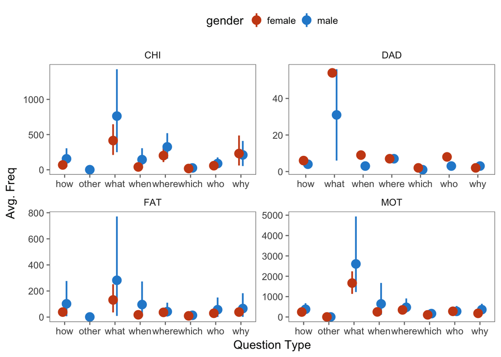

```r
gender_ms %>%
  ggplot(., aes(x = gloss_clean, y = mean, color = gender)) +
  geom_pointrange(aes(ymin = ci_lower, ymax = ci_upper),
                  position = position_dodge(width = 0.3), size = 0.8) +
  labs(y = "Avg. Freq", x= "Question Type") +
  langcog::scale_color_solarized() +
  facet_wrap(~speaker, scales = "free") +
  theme(legend.position = "top")
```

No gender differences in question words produced by kid or by mom.

### Context analyses

Here we will attempt to operationalize cost and reward of a behavior to get the value for a question.

### Complexity of utterance that each question word occurs in

Use some string functions to get the word count for each utterance.

```r
all_questions %<>%
  rowwise() %>%
  mutate(sentence_len = length(strsplit(sentgloss,' ')[[1]]))
```

Now summarise the mean sentence length for each question type for each kid and speaker

```r
sentence_len_ms <- all_questions %>%
  ungroup() %>%
  group_by(age_months, speaker_clean, child_clean, gloss_clean) %>%
  summarise(m.ss = median(sentence_len),
            n = n()) %>%
  group_by(age_months, speaker_clean, gloss_clean) %>%
  summarise(m = mean(m.ss),
            n = n())
```

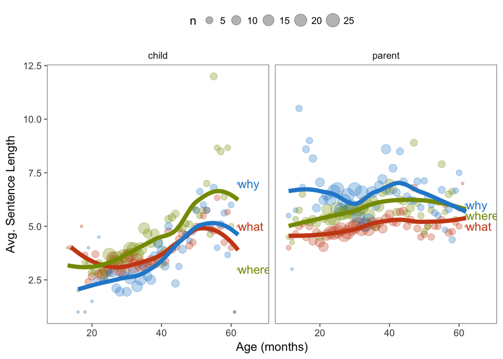

```r
sentence_len_ms %>%
  filter(gloss_clean %in% c("where", "what", "why")) %>%
  ggplot(data = ., aes(x = age_months, y = m, color = gloss_clean)) +
  geom_point(aes(size = n), alpha = 0.3) +
  geom_smooth(se=F, method = "loess", size = 2) +
  xlim(10, 68) +
  labs(y = "Avg. Sentence Length", x = "Age (months)") +
  guides(color = F) +
  langcog::scale_color_solarized() +
  geom_dl(aes(label = gloss_clean), method=list("last.points")) +
  facet_wrap(~speaker_clean) +
  theme(legend.position = "top")
```

### Single question word utterances

```r
single_words <- all_questions %>%
  filter(sentence_len == 1) %>%
  group_by(speaker_clean, child_clean, gloss_clean, age_months, length_transcript) %>%
  summarise(freq = n()) %>%
  mutate(prop = freq / length_transcript) %>%
  group_by(speaker_clean, gloss_clean, age_months) %>%
  summarise(m.ss = median(prop),
            n = n())
```

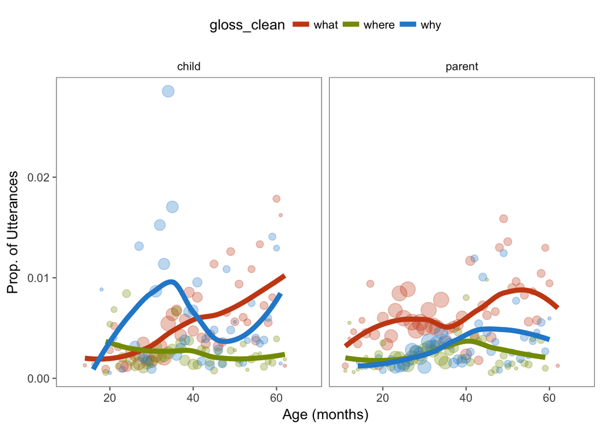

```r
single_words %>%
  filter(gloss_clean %in% c("where", "what", "why")) %>%
  ggplot(data = ., aes(x = age_months, y = m.ss, color = gloss_clean)) +
  geom_point(aes(size = n), alpha = 0.3) +
  geom_smooth(se=F, method = "loess", size = 2) +
  xlim(10, 68) +
  guides(size = F) +
  labs(y = "Prop. of Utterances", x = "Age (months)") +
  langcog::scale_color_solarized() +
  facet_wrap(~speaker_clean) +
  theme(legend.position = "top")
```

### Other analyeses to do: